# Bikeshare Demand Forecast

### by Simon Park, 2/8/2020

Goal: forecast bike rental demand in the Capital Bikeshare program in Washington D.C.

```python
import pandas as pd
import numpy as np
%matplotlib inline
import seaborn as sns
import matplotlib.pyplot as plt
import warnings
warnings.filterwarnings('ignore')
```

### Load the Data

In this section, we load the data and take a glimpse at it.

```python
train = pd.read_csv("Bike_train.csv")
test = pd.read_csv("Bike_test.csv")
print(train.shape)
print(test.shape)
train.head()
```

```
(10932, 14)
(6493, 13)
```

|  | daylabel | year | month | day | hour | season | holiday | workingday | weather | temp | atemp | humidity | windspeed | count |
| --- | --- | --- | --- | --- | --- | --- | --- | --- | --- | --- | --- | --- | --- | --- |
| 0 | 1 | 2011 | 1 | 1 | 0 | 1 | 0 | 0 | 1.0 | 9.84 | 14.395 | 81.0 | 0.0 | 16 |
| 1 | 1 | 2011 | 1 | 1 | 1 | 1 | 0 | 0 | 1.0 | 9.02 | 13.635 | 80.0 | 0.0 | 40 |
| 2 | 1 | 2011 | 1 | 1 | 2 | 1 | 0 | 0 | 1.0 | 9.02 | 13.635 | 80.0 | 0.0 | 32 |
| 3 | 1 | 2011 | 1 | 1 | 3 | 1 | 0 | 0 | 1.0 | 9.84 | 14.395 | 75.0 | 0.0 | 13 |
| 4 | 1 | 2011 | 1 | 1 | 4 | 1 | 0 | 0 | 1.0 | 9.84 | 14.395 | 75.0 | 0.0 | 1 |

```python
X_train = train.drop("count", axis=1)
y_train = train["count"]
```

The training data has 14 columns and 10932 observations.

The test data has 13 columns (which excludes our target variable **count**) and 6493 observations.

### Variable Importance

In this section, we provide the reasoning behind our selection of variables and the logic behind data transformations we made, if any.

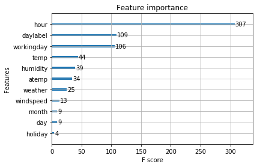

```python
from xgboost import XGBRegressor
from xgboost import plot_importance

model = XGBRegressor(objective='reg:squarederror', seed=37)
model.fit(X_train, y_train)
plot_importance(model)
plt.show()
```

Here we present a variable importance plot using XGboost built-in function. This is a good starting point, however, we go deep into data examination below.

### Year / Month / Day / Hour / Daylabel

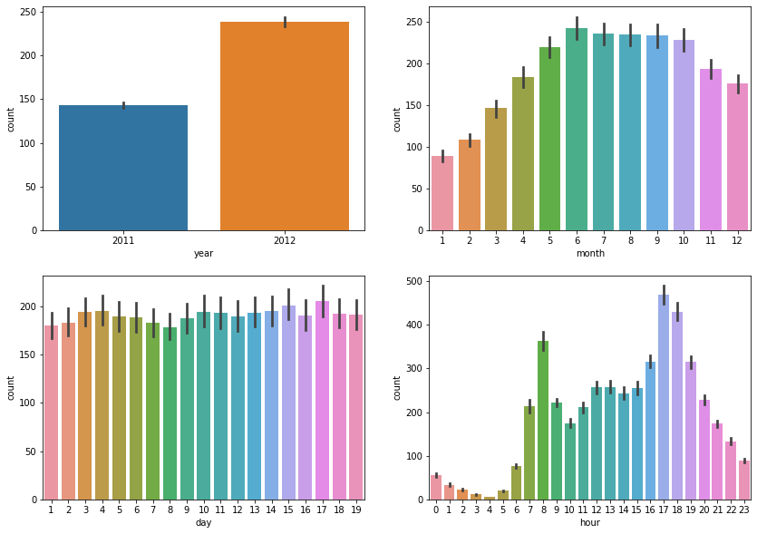

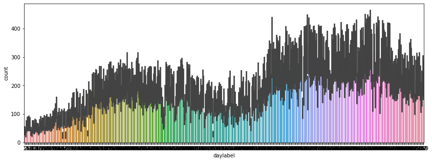

```python
figure, ((ax1, ax2), (ax3, ax4)) = plt.subplots(nrows=2, ncols=2)
figure.set_size_inches(14, 10)

sns.barplot(data=train, x="year", y="count", ax=ax1)
sns.barplot(data=train, x="month", y="count", ax=ax2)
sns.barplot(data=train, x="day", y="count", ax=ax3)
sns.barplot(data=train, x="hour", y="count", ax=ax4)

figure, ax5 = plt.subplots(nrows=1, ncols=1)
figure.set_size_inches(14, 5)

sns.barplot(data=train, x="daylabel", y="count", ax=ax5)
```

**year**

- 2012 has higher demand than 2011. This is because the company is growing, as illustrated in **daylabel** column.

**month**

- The demand is concentrated on June to August. There is a noticeble drop in demand during December to Februrary.
- However, notice that December has twice as much demand compared to Janurary.
  - This variable is further inspected in the later section. (spoiler: will be dropped)

**day**

- The training data only contains day 1 to 19 of each month, while the test data contains day 20 and onward. We believe this is susceptible to overfitting the data.
  - This variable is dropped in our specification.

**hour**

- The demand generally is high during the daytime and low during the nighttime.
- There are two peaks: 7 to 9 and 16 to 19, which are rush hours.
  - This variable is further inspected in the later section.

**daylabel**

- This column, at a first glance, contains the largest amount of information.
- Especially, above plot illustrates seasonal temporal trend.
  - This variable is further inspected in the later section. (spoiler: it will be transformed)

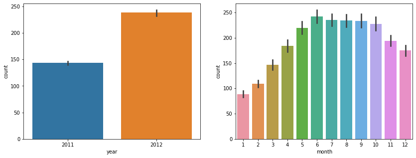

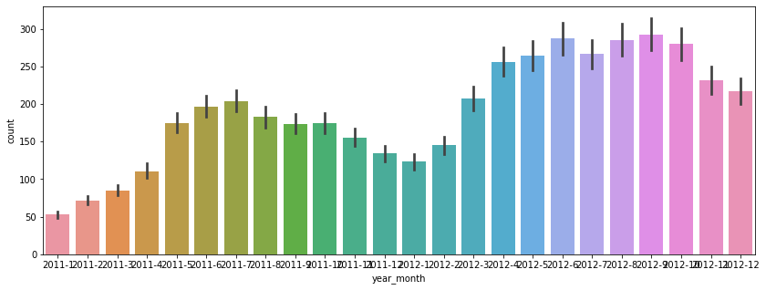

```python
train["year_month"] = train["year"].astype('str') + "-" + train["month"].astype('str')

figure, (ax1, ax2) = plt.subplots(nrows=1, ncols=2)
figure.set_size_inches(14, 5)

sns.barplot(data=train, x="year", y="count", ax=ax1)
sns.barplot(data=train, x="month", y="count", ax=ax2)

figure, ax3 = plt.subplots(nrows=1, ncols=1)
figure.set_size_inches(14, 5)

sns.barplot(data=train, x="year_month", y="count", ax=ax3)

train = train.drop("year_month", axis=1)
```

This clearly tells us that the reason December has a doublefold demand is 1) the company is growing; and 2) the data is available from 2011-1 to 2012-12, i.e. December has higher demand due to the growth. We believe that this is also susceptible to overfitting. We have an option to use one-hot key encoding on **year_month** variable to deal with this issue in theory. However, factors do not work with XGboost very well and therefore we instead drop **month** column to prevent overfitting.

### Hour / Workingday

```python
train["dayofweek"] = train["daylabel"]%7
train[["daylabel", "workingday", "dayofweek"]].drop_duplicates().head(10)
```

|  | daylabel | workingday | dayofweek |
| --- | --- | --- | --- |
| 0 | 1 | 0 | 1 |
| 24 | 2 | 0 | 2 |
| 48 | 3 | 1 | 3 |
| 72 | 4 | 1 | 4 |
| 96 | 5 | 1 | 5 |
| 120 | 6 | 1 | 6 |
| 144 | 7 | 1 | 0 |
| 168 | 8 | 0 | 1 |
| 192 | 9 | 0 | 2 |
| 216 | 10 | 1 | 3 |

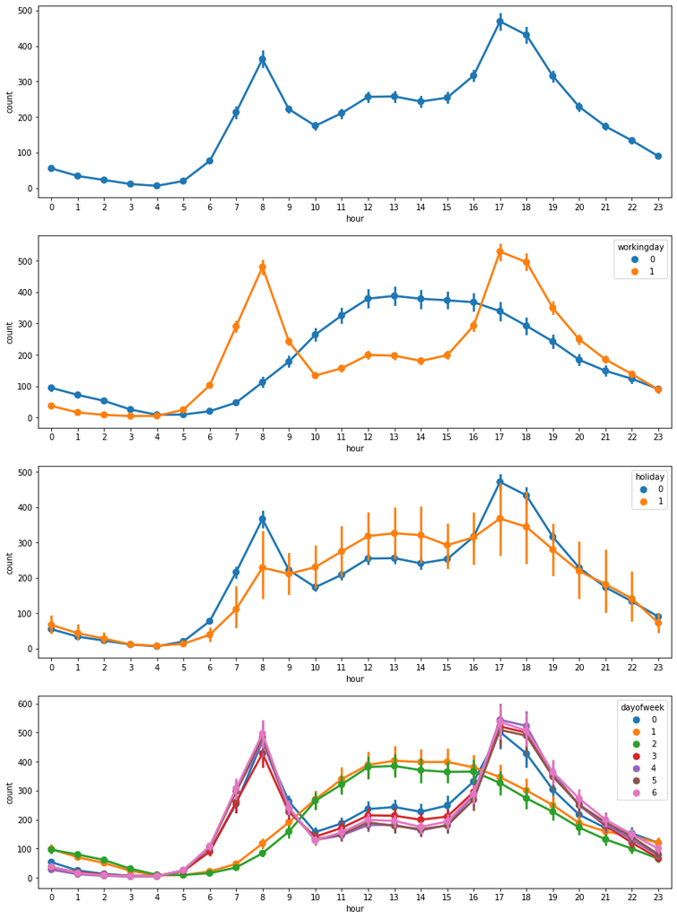

```python
figure, (ax1, ax2, ax3, ax4) = plt.subplots(nrows=4, ncols=1)
figure.set_size_inches(14, 20)

sns.pointplot(data=train, x="hour", y="count", ax=ax1)
sns.pointplot(data=train, x="hour", y="count", hue="workingday", ax=ax2)
sns.pointplot(data=train, x="hour", y="count", hue="holiday", ax=ax3)
sns.pointplot(data=train, x="hour", y="count", hue="dayofweek", ax=ax4)
```

### Atemp / Humidity

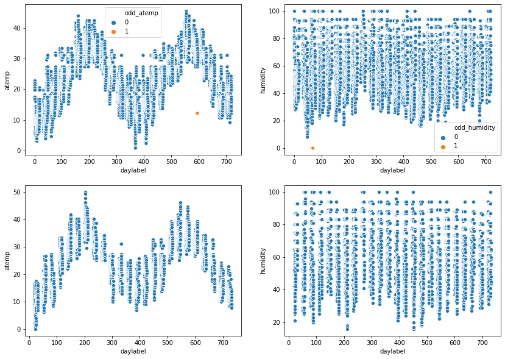

```python
train["odd_atemp"] = train["odd_humidity"] = 0
train["odd_atemp"][train.daylabel == 595] = 1
train["odd_humidity"][train.daylabel == 69] = 1

figure, ((ax1, ax2), (ax3, ax4)) = plt.subplots(nrows=2, ncols=2)
figure.set_size_inches(14, 10)

sns.scatterplot(data=train, x="daylabel", y="atemp", hue="odd_atemp", ax=ax1)
sns.scatterplot(data=train, x="daylabel", y="humidity", hue="odd_humidity", ax=ax2)
sns.scatterplot(data=test, x="daylabel", y="atemp", ax=ax3)
sns.scatterplot(data=test, x="daylabel", y="humidity", ax=ax4)

train = train.drop(["odd_atemp", "odd_humidity"], axis=1)
```

```python
train[(train.daylabel > 590) & (train.daylabel < 600) & (train.atemp < 20)].head(5)
```

|  | daylabel | year | month | day | hour | season | holiday | workingday | weather | temp | atemp | humidity | windspeed | count | dayofweek |
| --- | --- | --- | --- | --- | --- | --- | --- | --- | --- | --- | --- | --- | --- | --- | --- |
| 10476 | 595 | 2012 | 8 | 17 | 0 | 3 | 0 | 1 | 1.0 | 27.88 | 12.12 | 57.0 | 11.0014 | 88 | 0 |
| 10477 | 595 | 2012 | 8 | 17 | 1 | 3 | 0 | 1 | 1.0 | 27.06 | 12.12 | 65.0 | 7.0015 | 54 | 0 |
| 10478 | 595 | 2012 | 8 | 17 | 2 | 3 | 0 | 1 | 1.0 | 27.06 | 12.12 | 61.0 | 8.9981 | 19 | 0 |
| 10479 | 595 | 2012 | 8 | 17 | 3 | 3 | 0 | 1 | 1.0 | 26.24 | 12.12 | 65.0 | 7.0015 | 6 | 0 |
| 10480 | 595 | 2012 | 8 | 17 | 4 | 3 | 0 | 1 | 1.0 | 26.24 | 12.12 | 73.0 | 11.0014 | 9 | 0 |

```python
train[train.daylabel == 69].head(5)
```

|  | daylabel | year | month | day | hour | season | holiday | workingday | weather | temp | atemp | humidity | windspeed | count | dayofweek |
| --- | --- | --- | --- | --- | --- | --- | --- | --- | --- | --- | --- | --- | --- | --- | --- |
| 936 | 69 | 2011 | 3 | 10 | 0 | 1 | 0 | 1 | 3.0 | 13.94 | 15.9100 | 0.0 | 16.99790 | 3 | 6 |
| 937 | 69 | 2011 | 3 | 10 | 1 | 1 | 0 | 1 | 3.0 | 13.94 | 15.9100 | 0.0 | 16.99790 | 2 | 6 |
| 938 | 69 | 2011 | 3 | 10 | 2 | 1 | 0 | 1 | 3.0 | 13.94 | 15.9100 | 0.0 | 16.99790 | 1 | 6 |
| 939 | 69 | 2011 | 3 | 10 | 3 | 1 | 0 | 1 | 3.0 | 14.35 | 16.6675 | 0.0 | 14.99795 | 0 | 6 |
| 940 | 69 | 2011 | 3 | 10 | 4 | 1 | 0 | 1 | 3.0 | 14.35 | 16.6675 | 0.0 | 14.99795 | 0 | 6 |

The above plot shows one day in the training data with weird atemp record and another day with abnormal humidity.

We find the days that are odd in each variable and report them above, respectively. We find

1. **daylabel=595** reports **atemp=12.12** for every hour recorded that day, which is obviously a recording mistake given that temp varies.
2. **daylabel=69**: reports **humidity=0.0** for every hour recorded that day, which again can be seen an obvious recording mistake.

However, the observations do contain valuable information in other columns and after trial-and-error (with results that are not reported in this document) we decide to keep the observations.

### Weather / Season / Windspeed

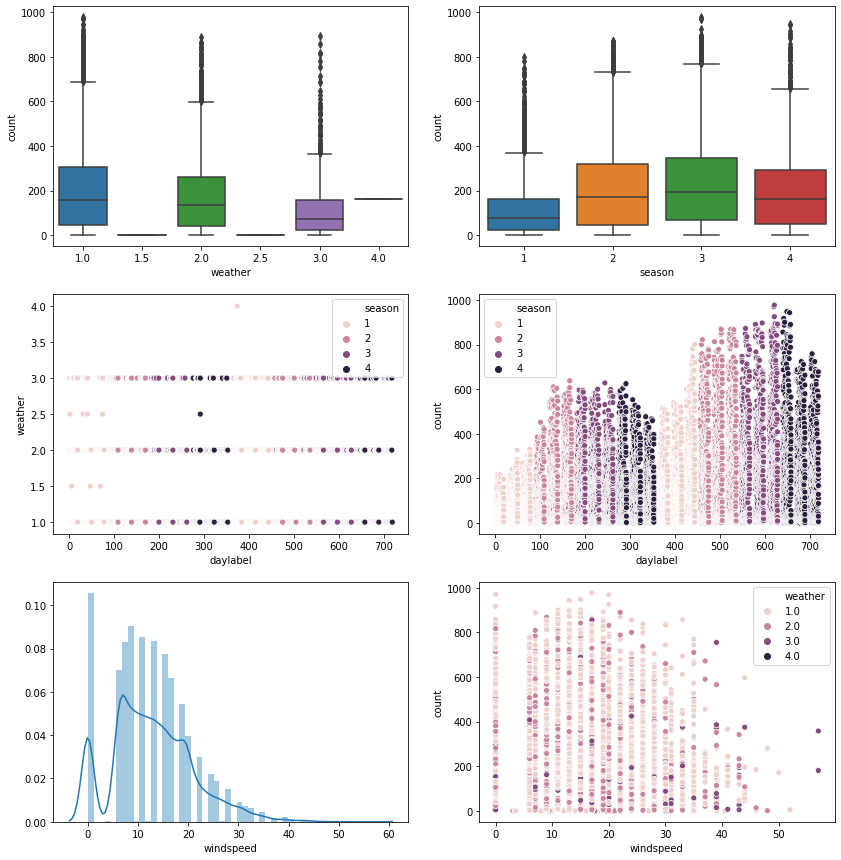

```python
figure, ((ax1, ax2), (ax3, ax4), (ax5, ax6)) = plt.subplots(nrows=3, ncols=2)
figure.set_size_inches(14, 15)

sns.boxplot(data=train, x="weather", y="count", ax=ax1)
sns.boxplot(data=train, x="season", y="count", ax=ax2)
sns.scatterplot(data=train, x="daylabel", y="weather", hue="season", ax=ax3)
sns.scatterplot(data=train, x="daylabel", y="count", hue="season", ax=ax4)
sns.distplot(train["windspeed"], ax=ax5)
sns.scatterplot(data=train, x="windspeed", y="count", hue="weather", ax=ax6)
```

```python
print(test["weather"].unique())
```

```
[1 2 3 4]
```

The above plots show seasonality patterns. We find some abnormality in **weather** variable, that is observations with .5 inputs. We conclude that thoes are the days in-between 1/2 or 2/3 and keep the observations for the same reason as above.

### count

```python
train["log_count"] = np.log(train["count"] + 1)
train[["count", "log_count"]].head()
train["rev_count"] = np.exp(train["log_count"]) - 1

train[["count", "log_count", "rev_count"]].head()
```

|  | count | log_count | rev_count |
| --- | --- | --- | --- |
| 0 | 16 | 2.833213 | 16.0 |
| 1 | 40 | 3.713572 | 40.0 |
| 2 | 32 | 3.496508 | 32.0 |
| 3 | 13 | 2.639057 | 13.0 |
| 4 | 1 | 0.693147 | 1.0 |

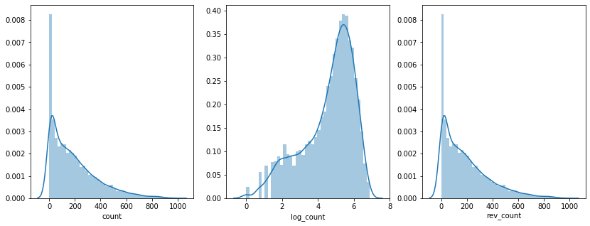

```python
figure, (ax1, ax2, ax3) = plt.subplots(nrows=1, ncols=3)
figure.set_size_inches(14, 5)

sns.distplot(train["count"], ax=ax1)
sns.distplot(train["log_count"], ax=ax2)
sns.distplot(train["rev_count"], ax=ax3)
```

It appears that **count** has a skewed distribution as it is highly concentrated on 0-20 counts and streatches out to nearly 1000 counts. To mitigate the issue, we implement log transformation to make underlying distribution resemble gaussian distribution.

Notice that we need to convert **log_count** back after making predictions, which is illustrated on **rev_count** using exponential transformation.

## Train

```python
feature_names = ["season", "holiday", "workingday", "weather",
                 "temp", "atemp", "humidity", "windspeed",
                 "year", "hour", "dayofweek"]
label_name = "log_count"
```

```python
X_train = train[feature_names]
print(X_train.shape)
X_train.head()
```

```
(10932, 11)
```

|  | season | holiday | workingday | weather | temp | atemp | humidity | windspeed | year | hour | dayofweek |
| --- | --- | --- | --- | --- | --- | --- | --- | --- | --- | --- | --- |
| 0 | 1 | 0 | 0 | 1.0 | 9.84 | 14.395 | 81.0 | 0.0 | 2011 | 0 | 1 |
| 1 | 1 | 0 | 0 | 1.0 | 9.02 | 13.635 | 80.0 | 0.0 | 2011 | 1 | 1 |
| 2 | 1 | 0 | 0 | 1.0 | 9.02 | 13.635 | 80.0 | 0.0 | 2011 | 2 | 1 |
| 3 | 1 | 0 | 0 | 1.0 | 9.84 | 14.395 | 75.0 | 0.0 | 2011 | 3 | 1 |
| 4 | 1 | 0 | 0 | 1.0 | 9.84 | 14.395 | 75.0 | 0.0 | 2011 | 4 | 1 |

```python
test["dayofweek"] = test["daylabel"]%7

X_test = test[feature_names]
print(X_test.shape)
X_test.head()
```

```
(6493, 11)
```

|  | season | holiday | workingday | weather | temp | atemp | humidity | windspeed | year | hour | dayofweek |
| --- | --- | --- | --- | --- | --- | --- | --- | --- | --- | --- | --- |
| 0 | 1 | 0 | 1 | 1 | 10.66 | 11.365 | 56 | 26.0027 | 2011 | 0 | 6 |
| 1 | 1 | 0 | 1 | 1 | 10.66 | 13.635 | 56 | 0.0000 | 2011 | 1 | 6 |
| 2 | 1 | 0 | 1 | 1 | 10.66 | 13.635 | 56 | 0.0000 | 2011 | 2 | 6 |
| 3 | 1 | 0 | 1 | 1 | 10.66 | 12.880 | 56 | 11.0014 | 2011 | 3 | 6 |
| 4 | 1 | 0 | 1 | 1 | 10.66 | 12.880 | 56 | 11.0014 | 2011 | 4 | 6 |

```python
y_train = train[label_name]
print(y_train.shape)
y_train.head()
```

```
(10932,)
```

```
0    2.833213
1    3.713572
2    3.496508
3    2.639057
4    0.693147
Name: log_count, dtype: float64
```

### Evaluation Standards

In this section, we develop a scorer function based on our evaluation standards.

Predictions will be evaluated using the root mean squared error (RMSE), calculated as $$ \text{RMSE} \equiv \sqrt{\frac{1}{n} \sum_{i=1}^n (p_i - a_i)^2 } $$

where $a_i$ is the true count (actual), $p_i$ is the estimate (prediction), and $n$ is the number of entries to be evaluated.

```python
from sklearn.metrics import make_scorer

def rmse(predict, actual):
    p = np.array(predict)
    a = np.array(actual)
    e = predict - actual
    se = e ** 2
    mse = se.mean()
    rmse = np.sqrt(mse)
    return rmse

rmse_scorer = make_scorer(rmse)
rmse_scorer
```

```
make_scorer(rmse)
```

## Hyperparameter Tuning

In this section, we tune our GBM hyperparameters using XGboost and sklearn modules.

*(**Note**) this section is very costly and thus the computation takes a long time. For that reason, the best hyperparmeters are saved below for reproducibility.*

```python
from sklearn.model_selection import cross_val_score
import xgboost as xgb
xgb.XGBRegressor()
```

```
XGBRegressor(base_score=0.5, booster='gbtree', colsample_bylevel=1,
             colsample_bynode=1, colsample_bytree=1, gamma=0,
             importance_type='gain', learning_rate=0.1, max_delta_step=0,
             max_depth=3, min_child_weight=1, missing=None, n_estimators=100,
             n_jobs=1, nthread=None, objective='reg:linear', random_state=0,
             reg_alpha=0, reg_lambda=1, scale_pos_weight=1, seed=None,
             silent=None, subsample=1, verbosity=1)
```

The parameters that we look for include:

- **n_estimators**: denotes the number of trees.
- **max_depth**: used to control over-fitting as higher depth will allow model to learn relations very specific to a particular sample.
- **learning_rate**: makes the model more robust by shrinking the weights on each step.
- **subsample**: denotes the fraction of observations to be randomly samples for each tree.
- **colsample_bytree**: denotes the fraction of columns to be randomly samples for each tree.
- **colsample_bylevel**: denotes the subsample ratio of columns for each split, in each level.

We run a 10-fold CV.

```python
coarse_hyperparam_list = []
for search in range(100):
    n_estimators = np.random.randint(low=100, high=1000)
    max_depth = np.random.randint(low=2, high=100)
    learning_rate = 10 ** -np.random.uniform(low=0, high=2)
    subsample = np.random.uniform(low=0.1, high=1.0)
    colsample_bytree = np.random.uniform(low=0.3, high=1.0)
    colsample_bylevel = np.random.uniform(low=0.3, high=1.0)

    model = xgb.XGBRegressor(objective='reg:squarederror',
                             n_estimators=n_estimators,
                             max_depth=max_depth,
                             learning_rate=learning_rate,
                             subsample=subsample,
                             colsample_bylevel=colsample_bylevel,
                             colsample_bytree=colsample_bytree,
                             seed=37)

    score = cross_val_score(model, X_train, y_train, cv=10, scoring=rmse_scorer).mean()

    hyperparameters = {
        'search': search,
        'score': score,
        'n_estimators': n_estimators,
        'max_depth': max_depth,
        'learning_rate': learning_rate,
        'subsample': subsample,
        'colsample_bylevel': colsample_bylevel,
        'colsample_bytree': colsample_bytree,
    }
    coarse_hyperparam_list.append(hyperparameters)
    print(f"{search:2} n_estimators = {n_estimators}, max_depth = {max_depth:2}, learning_rate = {learning_rate:.10f}, subsample = {subsample:.6f}, colsample_bylevel = {colsample_bylevel:.6f}, colsample_bytree = {colsample_bytree:.6f}, Score = {score:.5f}")

coarse_hyperparam_list = pd.DataFrame.from_dict(coarse_hyperparam_list)
coarse_hyperparam_list = coarse_hyperparam_list.sort_values(by="score")
print(coarse_hyperparam_list.shape)
coarse_hyperparam_list.head(5)
```

After the coarse search, we retrieve min-max range of the hyperparameters and execute another random search, a finer search.

This time, we run a 20-fold CV.

```python
finer_hyperparam_list = []
for search in range(100):
    n_estimators = np.random.randint(low=300, high=1000)
    max_depth = np.random.randint(low=2, high=30)
    learning_rate = 10 ** -np.random.uniform(low=0, high=2)
    subsample = np.random.uniform(low=0.2, high=0.7)
    colsample_bytree = np.random.uniform(low=0.7, high=1.0)
    colsample_bylevel = np.random.uniform(low=0.4, high=1.0)

    model = xgb.XGBRegressor(objective='reg:squarederror',
                             n_estimators=n_estimators,
                             max_depth=max_depth,
                             learning_rate=learning_rate,
                             subsample=subsample,
                             colsample_bylevel=colsample_bylevel,
                             colsample_bytree=colsample_bytree,
                             seed=37)

    score = cross_val_score(model, X_train, y_train, cv=20, scoring=rmse_scorer).mean()

    hyperparameters = {
        'search': search,
        'score': score,
        'n_estimators': n_estimators,
        'max_depth': max_depth,
        'learning_rate': learning_rate,
        'subsample': subsample,
        'colsample_bylevel': colsample_bylevel,
        'colsample_bytree': colsample_bytree,
    }
    finer_hyperparam_list.append(hyperparameters)
    print(f"{search:2} n_estimators = {n_estimators}, max_depth = {max_depth:2}, learning_rate = {learning_rate:.10f}, subsample = {subsample:.6f}, colsample_bylevel = {colsample_bylevel:.6f}, colsample_bytree = {colsample_bytree:.6f}, Score = {score:.5f}")

finer_hyperparam_list = pd.DataFrame.from_dict(finer_hyperparam_list)
finer_hyperparam_list = finer_hyperparam_list.sort_values(by="score")
print(finer_hyperparam_list.shape)
finer_hyperparam_list.head(10)
```

```python
best_hyperparameters = finer_hyperparameters_list.iloc[0]

best_n_estimators = int(best_hyperparameters["n_estimators"])
best_max_depth = int(best_hyperparameters["max_depth"])
best_learning_rate = best_hyperparameters["learning_rate"]
best_subsample = best_hyperparameters["subsample"]
best_colsample_bytree = best_hyperparameters["colsample_bytree"]
best_colsample_bylevel = best_hyperparameters["colsample_bylevel"]

print(f"n_estimators(best) = {best_n_estimators}, max_depth(best) = {best_max_depth}, learning_rate(best) = {best_learning_rate:.6f}, subsample(best) = {best_subsample:.6f}, colsample_bytree(best) = {best_colsample_bytree:.6f}, colsample_bylevel(best) = {best_colsample_bylevel:.6f}")
```

Above code chunks produce the following results.

```python
best_n_estimators      = 859
best_max_depth         = 10
best_learning_rate     = 0.011105
best_subsample         = 0.362207
best_colsample_bytree  = 0.980396
best_colsample_bylevel = 0.870122
```

## Gradient Boosting Machine

GBM Gradient Boosting Machine) is known to have best perform for structured data, one of the most powerful machine learning algorithms. Therefore we use GBM, using `XGBRegressor` from XGBoost model. We define our medel with the best hyperparameters.

```python
model = xgb.XGBRegressor(objective='reg:squarederror',
                         n_estimators=best_n_estimators,
                         max_depth=best_max_depth,
                         learning_rate=best_learning_rate,
                         subsample=best_subsample,
                         colsample_bytree=best_colsample_bytree,
                         colsample_bylevel=best_colsample_bylevel,
                         seed=37)

model
```

```
XGBRegressor(base_score=0.5, booster='gbtree', colsample_bylevel=0.870122,
             colsample_bynode=1, colsample_bytree=0.980396, gamma=0,
             importance_type='gain', learning_rate=0.011105, max_delta_step=0,
             max_depth=10, min_child_weight=1, missing=None, n_estimators=859,
             n_jobs=1, nthread=None, objective='reg:squarederror',
             random_state=0, reg_alpha=0, reg_lambda=1, scale_pos_weight=1,
             seed=37, silent=None, subsample=0.362207, verbosity=1)
```

First, we fit the model on the training data.

```python
model.fit(X_train, y_train)
```

```
XGBRegressor(base_score=0.5, booster='gbtree', colsample_bylevel=0.870122,
             colsample_bynode=1, colsample_bytree=0.980396, gamma=0,
             importance_type='gain', learning_rate=0.011105, max_delta_step=0,
             max_depth=10, min_child_weight=1, missing=None, n_estimators=859,
             n_jobs=1, nthread=None, objective='reg:squarederror',
             random_state=0, reg_alpha=0, reg_lambda=1, scale_pos_weight=1,
             seed=37, silent=None, subsample=0.362207, verbosity=1)
```

Second, we make predictions on the test data.

```python
log_predictions = model.predict(X_test)
print(log_predictions.shape)
log_predictions
```

```
(6493,)
```

```
array([2.726132 , 1.7367213, 1.405391 , ..., 4.7072635, 4.4455194,
       3.833234 ], dtype=float32)
```

Third, for the reasons mentioned in the data section, we revert the log transformation for **count**.

```python
predictions = np.exp(log_predictions) - 1
print(predictions.shape)

predictions
```

```
(6493,)
```

```
array([ 14.273693 ,   4.678694 ,   3.0771203, ..., 109.74868  ,
        84.24415  ,  45.21175  ], dtype=float32)
```

## Submission

In this section, we save our predictions in .csv format following the instructions.

```python
submission = pd.read_csv("hw2-mkolar.csv")
submission.head()
```

|  | count |
| --- | --- |
| 0 | 0.000000 |
| 1 | 0.000000 |
| 2 | 0.000000 |
| 3 | 0.000000 |
| 4 | 0.379271 |

```python
submission["count"] = predictions
print(submission.shape)

submission.head()
```

```
(6493, 1)
```

|  | count |
| --- | --- |
| 0 | 14.273693 |
| 1 | 4.678694 |
| 2 | 3.077120 |
| 3 | 2.229180 |
| 4 | 1.655136 |

```python
submission.to_csv("hw3-simonpark.csv", index=False)
```

Sepcial thanks to Jina Hur (Uchicago Harris), who discussed with us to formulate ideas on how to approach this problem